# Exploring Spotify API in R

In this short piece work I would like to explore how to access Spotify data with the help of **spotifyr-package** and which various interesting things can be done with it. The following explorative analysis is of relevance for music industry professionals, music analysts as well as music lovers.

## Short summary

The article is structured as follows: firstly, the basic packages are downloaded and Spotify data is accessed, then the explorative analysis is focused on the visualization of some music features and lyrics based on Lorde’s music.

## Downloading packages

To access Spotify API, additional packages need to be downloaded. Notice that package **spotifyr** has been removed from CRAN recently, therefore, here is the alternative way of downloading this package.

```r
library(devtools)
```

```
## Error in get(genname, envir = envir) : object 'testthat_print' not found
```

```r
devtools::install_github('charlie86/spotifyr')
library(spotifyr)
library(tidyverse)
library(knitr)
```

To access the Spotify data, the corresponding credentials should be specified. More information on accessing Spotify for Spotify credentials can be found here https://www.rcharlie.com/spotifyr/. To proceed, we need to create 3 ID-related variables based on the information from our Spotify for Developers account.

```r
#Sys.setenv(SPOTIFY_CLIENT_ID = 'XXX')
#Sys.setenv(SPOTIFY_CLIENT_SECRET = 'XXX')
#access_token <- get_spotify_access_token()
```

## Explorative data analysis

```r
lorde <- get_artist_audio_features('lorde')
lorde %>%
  arrange(-valence)%>% #decreasing
  select(track_name, valence)
```

```
##                    track_name valence
## 1               The Love Club  0.6260
## 2              Perfect Places  0.5250
## 3              Perfect Places  0.5250
## 4                       Sober  0.5160
## 5                       Sober  0.5160
## 6              Perfect Places  0.5120
## 7              Perfect Places  0.5120
## 8                       Sober  0.4620
## 9                       Sober  0.4620
## 10       Million Dollar Bills  0.4370
## 11               Tennis Court  0.4280
## 12                       Team  0.4160
## 13                       Team  0.4160
## 14                       Team  0.4160
```

[output cut: 70 more lines]

**Indeed Lorde’s song “The Love Club” has the highest valence of 0.6**, with other famous songs such as “Perfect Places”, “Tennis Court”, “Team” having lower degree of positiveness.

We can also find the mean **valence** for each of the Lorde’s albums.

```r
lorde %>%
  group_by (album_name) %>%
  summarise(mean(valence)) %>%
  arrange(desc('mean(valence)'))
```

```
## # A tibble: 3 x 2
##   album_name              `mean(valence)`
##   <chr>                             <dbl>
## 1 Melodrama                         0.269
## 2 Pure Heroine                      0.208
## 3 Pure Heroine (Extended)           0.249
```

**Apparently, the most recent album of Lorde “Melodrama” is the most positive one, with the mean valence of 0.27.**

To get a better understanding of the **valence** data, we can visualize it. For this, we need **ggjoy-package.**

```r
library(ggjoy)
```

After installing the package we can plot the **valence** (=musical positiveness) of Lorde’s major albums.

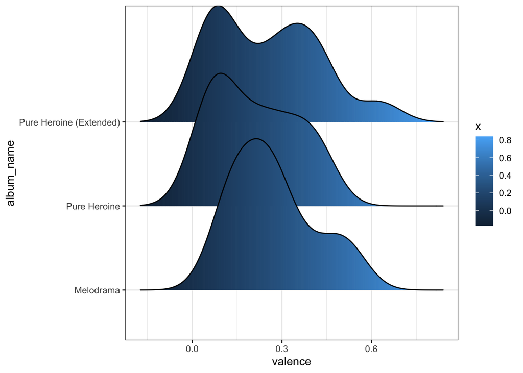

```r
ggplot(lorde, aes(x = valence, y = album_name, fill = ..x..)) + geom_density_ridges_gradient() +
  theme(legend.position = "none") + theme_bw()
```

In the graph above we can see the density-plots of valence for Lorde’s three major albums: “Melodrama”, “Pure Heroine” and “Pure Heroine (Extended)”. The plots can be interpeted in the following way: if you group together all valence-values for each of the albums, they pick around 0.1 for “Pure Heroine” and its extended version, while for “Melodrama” the valence picks at 0.2 or so. **Therefore, we can claim that Lorde’s albums are not that positive, according to Spotify data.**

Another interesting thing to do with our data is to combine it with lyrics. For this we need to use **genius-package.**

```r
library(genius)
```

Now let’s test it on “Pure Heroine” album of Lorde.

```r
pure_heroine <-genius_album(artist = "Lorde", album = "Pure Heroine")
```

For further analysis based on lyrics, we need an additional package.

```r
library(tidytext)
```

Now let’s view the lyrics…

```r
View(pure_heroine)
```

…and join the lyrics data.

```r
pure_heroine %>%
  unnest_tokens(word, lyric) %>%
  anti_join(stop_words) %>%
  inner_join(get_sentiments("bing")) -> pure_heroine_words
```

Furthermore, we can visualize the lyrics.

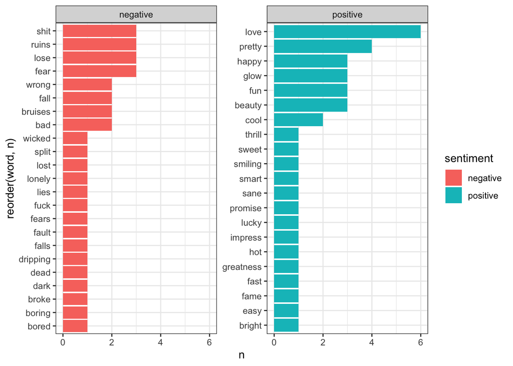

```r
pure_heroine_words %>%
  count(word, sentiment, sort = TRUE) %>%
  ggplot(aes(reorder(word,n), n, fill = sentiment)) + geom_col() + coord_flip() + facet_wrap(~sentiment, scales = "free_y") + theme_bw()
```

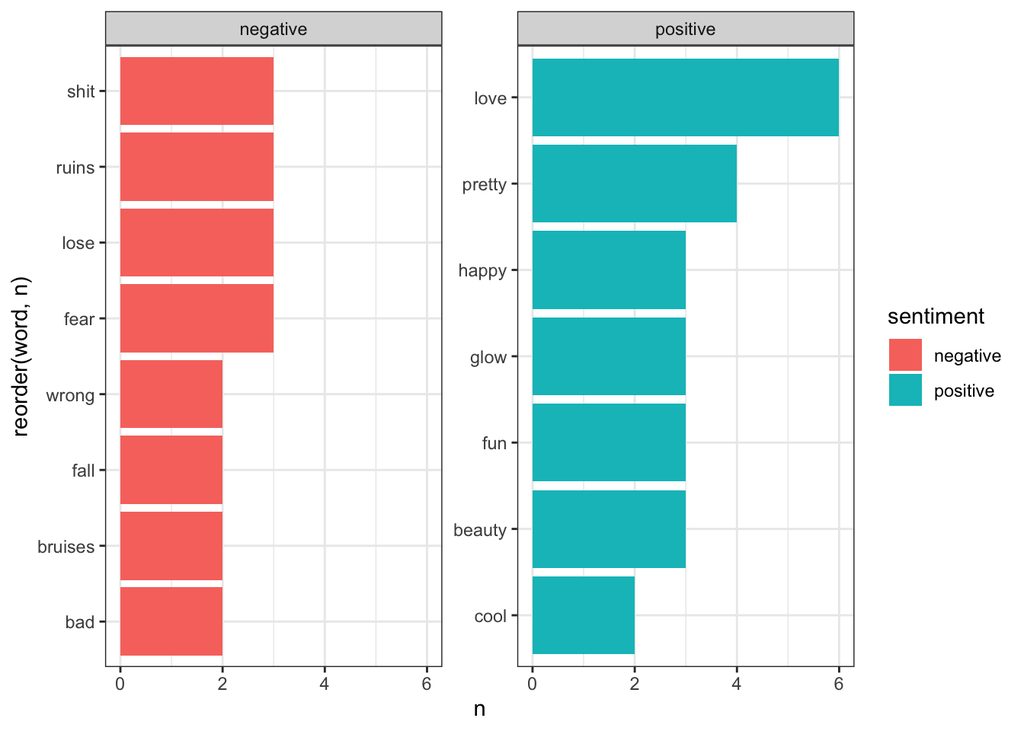

```r
pure_heroine_words %>%
  count(word, sentiment, sort = TRUE) %>%
  filter(n >1) %>%
  ggplot(aes(reorder(word,n), n, fill = sentiment)) + geom_col() + coord_flip() + facet_wrap(~sentiment, scales = "free_y") + theme_bw()
```

Here is another visualization option.

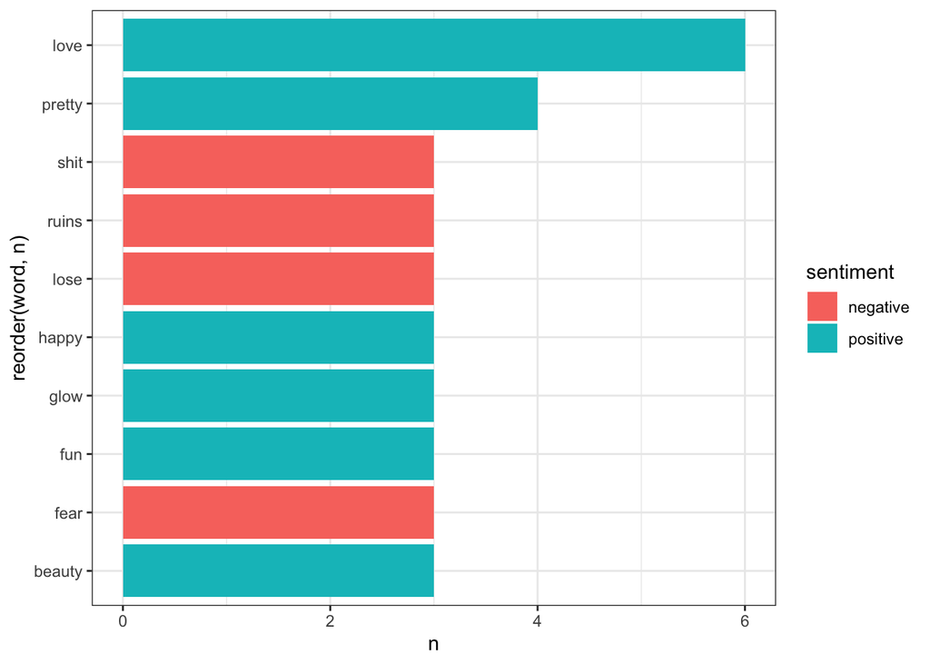

```r
pure_heroine_words %>%
  count(word, sentiment, sort = TRUE) %>%
  arrange (desc(n)) %>%
  head(10) %>%
  ggplot(aes(reorder(word,n),n, fill = sentiment)) + geom_col() + coord_flip() + theme_bw()
```

**It’s worth noting that despite “Pure Heroine” having a low valence (0.21), the most frequent words in this album are classified as positive, rather than negative.**

But can we create a density plot of a sentiment of the lyrics from the Lorde’s album “Pure Heroine”? Indeed, for this purpose we can use the code from above.

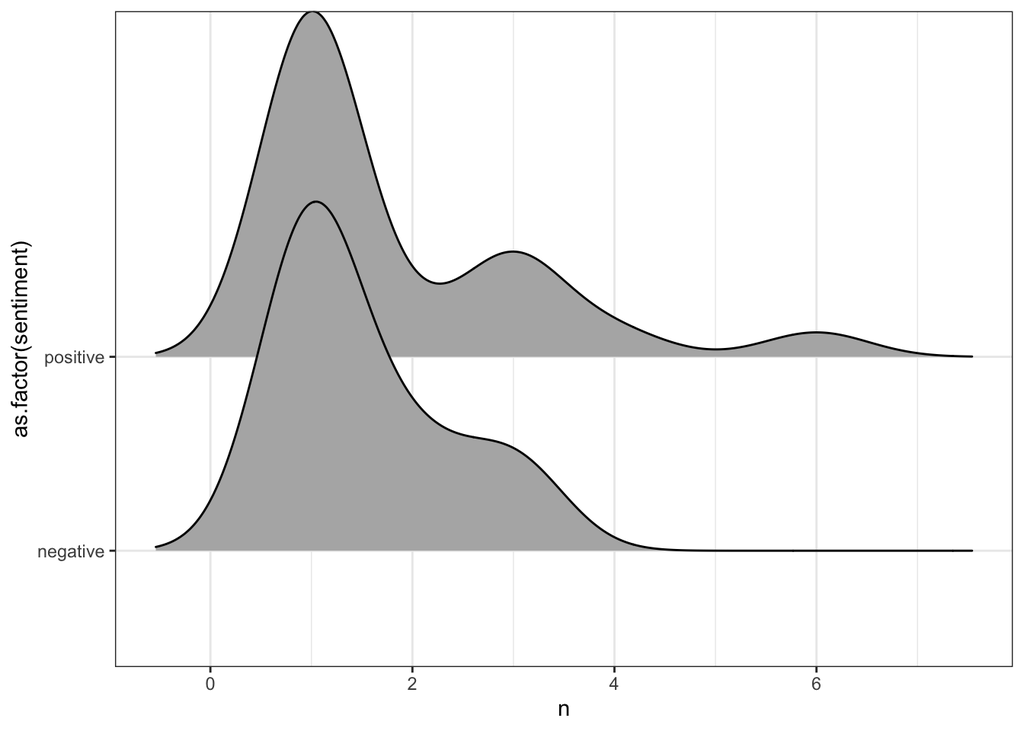

```r
pure_heroine_words %>%
  count(word, sentiment, sort = TRUE) %>%
  arrange(desc(n)) %>%
  ggplot(aes(x = n, y = as.factor(sentiment))) + geom_density_ridges() + theme_bw()
```

So far, we’ve covered the valence and lyrics of Lorde’s tracks. In the end, we can also try visualizing keys.

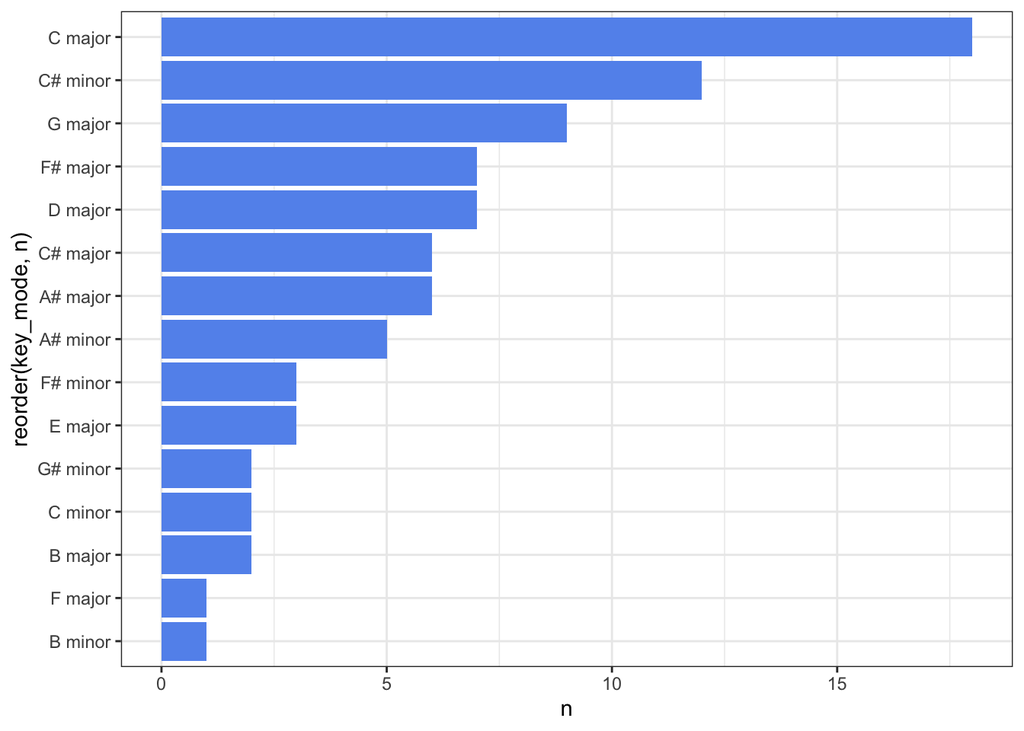

```r
lorde %>%
  count(key_mode, sort = TRUE) %>%
  ggplot(aes(reorder(key_mode, n), n))+
  geom_col(fill = "#6495ED") + coord_flip() + theme_bw()
```

**Here we can see that C major is significantly prevailing in Lorde’s albums.** According to the Austrian composer and pianist Ernst Pauer (1826–1905), C major has such characteristics as *“a pure, certain and decisive manner, full of innocence, earnestness, deepest religious feeling.” As an example of C major, Ernst Pauer cited works by Mozart, Weber, Beethoven, Mendelssohn, and Haydn.*

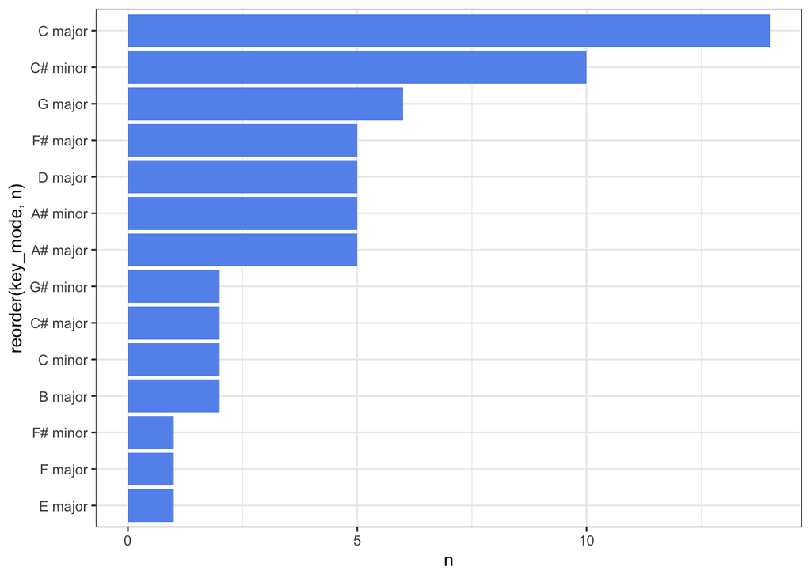

```r
lorde %>%
  filter(!album_name %in% c("Pure Heroine")) %>%
  count(key_mode, sort = TRUE) %>%
  ggplot(aes(reorder(key_mode, n), n))+
  geom_col(fill = "#6495ED") + coord_flip() + theme_bw()
```

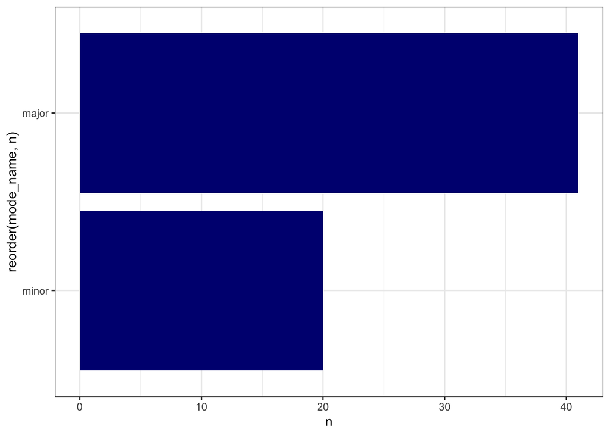

```r
lorde %>%
  filter(!album_name %in% c("Pure Heroine")) %>%
  count(mode_name, sort = TRUE) %>%
  ggplot(aes(reorder(mode_name, n), n))+
  geom_col(fill = "#000080") + coord_flip() + theme_bw()
```

In conclusion, Spotify API data represents a lot of different features than can be analyzed with the help of **spotifyr-package**. The above exploratory analysis has demonstrated not only the analysis of different music features but also provided a look into the lyrics of Lorde’s songs.